# Airline Flights Data Exploration

## Preliminary Wrangling

```python
import pandas as pd
import matplotlib.pyplot as plt
import seaborn as sb
import numpy as np
```

```python
flights = pd.read_csv('flight_data_2008.csv')
```

```python
flights.head()
```

|  | Year | Month | DayofMonth | DayOfWeek | DepTime | CRSDepTime | ArrTime | CRSArrTime | UniqueCarrier | FlightNum | ... | TaxiIn | TaxiOut | Cancelled | CancellationCode | Diverted | CarrierDelay | WeatherDelay | NASDelay | SecurityDelay | LateAircraftDelay |
| --- | --- | --- | --- | --- | --- | --- | --- | --- | --- | --- | --- | --- | --- | --- | --- | --- | --- | --- | --- | --- | --- |
| 0 | 2008 | 1 | 3 | 4 | 1343.0 | 1325 | 1451.0 | 1435 | WN | 588 | ... | 4.0 | 9.0 | 0 | NaN | 0 | 16.0 | 0.0 | 0.0 | 0.0 | 0.0 |
| 1 | 2008 | 1 | 3 | 4 | 1125.0 | 1120 | 1247.0 | 1245 | WN | 1343 | ... | 3.0 | 8.0 | 0 | NaN | 0 | NaN | NaN | NaN | NaN | NaN |
| 2 | 2008 | 1 | 3 | 4 | 2009.0 | 2015 | 2136.0 | 2140 | WN | 3841 | ... | 2.0 | 14.0 | 0 | NaN | 0 | NaN | NaN | NaN | NaN | NaN |
| 3 | 2008 | 1 | 3 | 4 | 903.0 | 855 | 1203.0 | 1205 | WN | 3 | ... | 5.0 | 7.0 | 0 | NaN | 0 | NaN | NaN | NaN | NaN | NaN |
| 4 | 2008 | 1 | 3 | 4 | 1423.0 | 1400 | 1726.0 | 1710 | WN | 25 | ... | 6.0 | 10.0 | 0 | NaN | 0 | 16.0 | 0.0 | 0.0 | 0.0 | 0.0 |

5 rows × 29 columns

```python
flights.info()
```

```
<class 'pandas.core.frame.DataFrame'>
RangeIndex: 2389217 entries, 0 to 2389216
Data columns (total 29 columns):
 #   Column             Dtype
---  ------             -----
 0   Year               int64
 1   Month              int64
 2   DayofMonth         int64
 3   DayOfWeek          int64
 4   DepTime            float64
 5   CRSDepTime         int64
 6   ArrTime            float64
 7   CRSArrTime         int64
 8   UniqueCarrier      object
 9   FlightNum          int64
```

[output cut: 21 more lines]

There are 2389217 flights in the dataset with 29 features . Most variables are numeric in nature.

- 1 Year 2008
- 2 Month 1-12
- 3 DayofMonth 1-31
- 4 DayOfWeek 1 (Monday) - 7 (Sunday)
- 5 DepTime actual departure time (local, hhmm)
- 6 CRSDepTime scheduled departure time (local, hhmm)
- 7 ArrTime actual arrival time (local, hhmm)
- 8 CRSArrTime scheduled arrival time (local, hhmm)
- 9 UniqueCarrier unique carrier code
- 10 FlightNum flight number
- 11 TailNum plane tail number
- 12 ActualElapsedTime in minutes
- 13 CRSElapsedTime in minutes
- 14 AirTime in minutes
- 15 ArrDelay arrival delay, in minutes
- 16 DepDelay departure delay, in minutes
- 17 Origin origin IATA airport code
- 18 Dest destination IATA airport code
- 19 Distance in miles
- 20 TaxiIn taxi in time, in minutes
- 21 TaxiOut taxi out time in minutes
- 22 Cancelled was the flight cancelled?
- 23 CancellationCode reason for cancellation (A = carrier, B = weather, C = NAS, D = security)
- 24 Diverted 1 = yes, 0 = no
- 25 CarrierDelay in minutes
- 26 WeatherDelay in minutes
- 27 NASDelay in minutes
- 28 SecurityDelay in minutes
- 29 LateAircraftDelay in minutes ### What is/are the main feature(s) of interest in your dataset?

I'm most interested in figuring out what features are best for predicting whether the plane is Cancelled, Diverted, Delayed (and to what degree), or On time/ early.

### What features in the dataset do you think will help support your investigation into your feature(s) of interest?

I expect that the Carrier will have an effect on how often the plane is Cancelled, Diverted, Delayed, or On Time

## Univariate Exploration

I'll start by looking at the distribution of the main variable of interest: flight status. I will need to create this variable first through a nested np.where() statement

```python
flights['flight_status'] = np.where(flights.Cancelled, 'Cancelled', np.where(flights.Diverted, 'Diverted', np.where(flights.ArrDelay >= 15, 'Delayed', 'On Time/Early')))
```

```python
flights.head()
```

|  | Year | Month | DayofMonth | DayOfWeek | DepTime | CRSDepTime | ArrTime | CRSArrTime | UniqueCarrier | FlightNum | ... | TaxiOut | Cancelled | CancellationCode | Diverted | CarrierDelay | WeatherDelay | NASDelay | SecurityDelay | LateAircraftDelay | flight_status |
| --- | --- | --- | --- | --- | --- | --- | --- | --- | --- | --- | --- | --- | --- | --- | --- | --- | --- | --- | --- | --- | --- |
| 0 | 2008 | 1 | 3 | 4 | 1343.0 | 1325 | 1451.0 | 1435 | WN | 588 | ... | 9.0 | 0 | NaN | 0 | 16.0 | 0.0 | 0.0 | 0.0 | 0.0 | Delayed |
| 1 | 2008 | 1 | 3 | 4 | 1125.0 | 1120 | 1247.0 | 1245 | WN | 1343 | ... | 8.0 | 0 | NaN | 0 | NaN | NaN | NaN | NaN | NaN | On Time/Early |
| 2 | 2008 | 1 | 3 | 4 | 2009.0 | 2015 | 2136.0 | 2140 | WN | 3841 | ... | 14.0 | 0 | NaN | 0 | NaN | NaN | NaN | NaN | NaN | On Time/Early |
| 3 | 2008 | 1 | 3 | 4 | 903.0 | 855 | 1203.0 | 1205 | WN | 3 | ... | 7.0 | 0 | NaN | 0 | NaN | NaN | NaN | NaN | NaN | On Time/Early |
| 4 | 2008 | 1 | 3 | 4 | 1423.0 | 1400 | 1726.0 | 1710 | WN | 25 | ... | 10.0 | 0 | NaN | 0 | 16.0 | 0.0 | 0.0 | 0.0 | 0.0 | Delayed |

5 rows × 30 columns

### Graph barplot for count of each flight status

```
On Time/Early    1734538
Delayed           584583
Cancelled          64442
Diverted            5654
Name: flight_status, dtype: int64
```

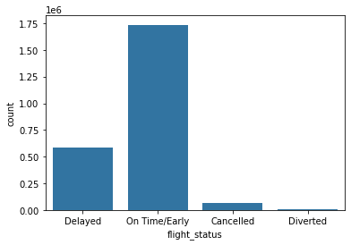

```python
base_color = sb.color_palette()[0]
sb.countplot(data = flights, x = 'flight_status', color = base_color);
flights.flight_status.value_counts()
```

- We have about 1.75 million On Time/ Early flights, half a million Delayed flights, and very few cancelled and diverted flights

```python
flights.UniqueCarrier.nunique()
```

```
20
```

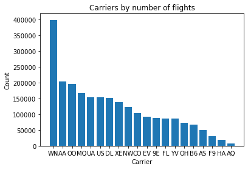

```python
plt.bar(flights.UniqueCarrier.value_counts().index, flights.UniqueCarrier.value_counts().values)
plt.xlabel('Carrier')
plt.ylabel('Count')
plt.title('Carriers by number of flights');
```

- It looks like the most frequent carrier in terms of flights 'WN' has close to double the flights even the next most frequent carrier

### Graph relative frequency for Day of the Week

```python
n_flights = len(flights)
max_dayofweek_count = flights.DayOfWeek.value_counts().values[0]
max_prop = max_dayofweek_count/ n_flights
max_prop
```

```
0.15300410134366196
```

```python
tick_props = np.arange(0, max_prop, 0.02)
tick_names = ['{:.2f}'.format(v) for v in tick_props]
tick_names
```

```
['0.00', '0.02', '0.04', '0.06', '0.08', '0.10', '0.12', '0.14']
```

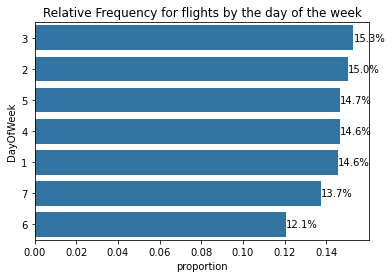

```python
sb.countplot(data = flights, y = 'DayOfWeek', color = base_color, order = flights.DayOfWeek.value_counts().index)
plt.xticks(tick_props * n_flights, tick_names)
plt.xlabel('proportion')
plt.title('Relative Frequency for flights by the day of the week')
for i in range(flights.DayOfWeek.value_counts().shape[0]):
    count = flights.DayOfWeek.value_counts().values[i]
    pct_string = '{:0.1f}%'.format(100*count/n_flights)
    plt.text(count+1, i, pct_string, va = 'center');
```

- Saturday and Sunday are when flights are less frequent, with Saturday contributing over 2.5% less to overall flights than the weekday average

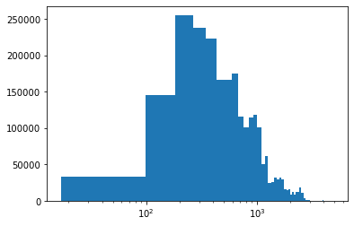

```python
plt.hist(flights.Distance, bins = 60)
plt.xscale('log');
```

- The distribution of flight distances appears to be close to normal when a log scale is applied

## Bivariate Exploration

### Create correlation heatmaps of flight status severity versus other quantitative variables in dataset

```python
flights['fs_severity'] = np.where(flights.flight_status == 'Cancelled', 3, np.where(flights.flight_status == 'Diverted', 2, np.where(flights.ArrDelay >= 15, 1, 0)))
```

```python
flights['Cancelled/Diverted'] = np.where(flights.flight_status == 'Cancelled', 1, np.where(flights.flight_status == 'Diverted', 1, 0))
```

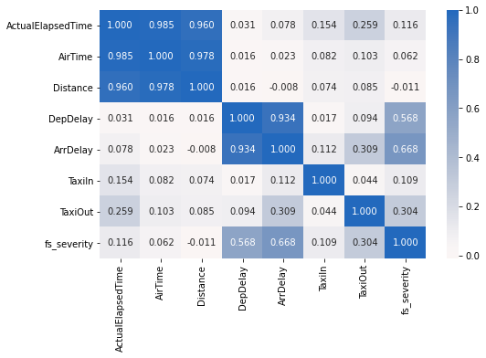

```python
plt.figure(figsize = [8, 5])
num_vars = ['ActualElapsedTime', 'AirTime', 'Distance', 'DepDelay','ArrDelay', 'TaxiIn', 'TaxiOut', 'fs_severity']
sb.heatmap(flights[num_vars].corr(), annot = True, fmt = '.3f',
           cmap = 'vlag_r', center = 0)
plt.show()
```

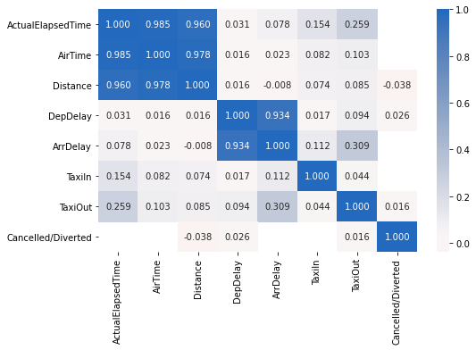

```python
plt.figure(figsize = [8, 5])
num_vars = ['ActualElapsedTime', 'AirTime', 'Distance', 'DepDelay','ArrDelay', 'TaxiIn', 'TaxiOut', 'Cancelled/Diverted']
sb.heatmap(flights[num_vars].corr(), annot = True, fmt = '.3f',
           cmap = 'vlag_r', center = 0)
plt.show()
```

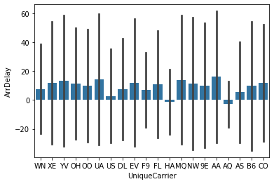

```python
sb.barplot(data = flights, x = 'UniqueCarrier', y = 'ArrDelay', ci = 'sd', color = base_color);
```

- The Carriers HA and AQ are the best airlines in terms of mean arrival time compared to expected arrival time

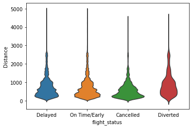

```python
sb.violinplot(data = flights, x = 'flight_status', y = 'Distance', inner = None);
```

- Flights that are Diverted are typically slightly longer in terms of Distance than other flight_statuses

### Find airports in the top 5 or bottom 5 proportion of flights with flight status Cancelled, Diverted, or Delayed

```python
problem_flights_by_airport = flights.query('flight_status == "Cancelled" or flight_status == "Diverted" or flight_status == "Delayed"').Dest.value_counts() + flights.query('flight_status == "Cancelled" or flight_status == "Diverted" or flight_status == "Delayed"').Origin.value_counts()
```

```python
pfba_prop = problem_flights_by_airport / (flights.Dest.value_counts() + flights.Origin.value_counts())
```

```python
pfba_prop.dropna(inplace = True)
airport_props = pd.DataFrame(pfba_prop.sort_values(ascending = False))
```

```python
airport_counts = flights.Origin.value_counts() + flights.Dest.value_counts()
```

```python
airport_counts = pd.DataFrame(airport_counts)
```

```python
airport_counts
```

|  | 0 |
| --- | --- |
| ABE | 3214.0 |
| ABI | 1764.0 |
| ABQ | 27140.0 |
| ABY | 836.0 |
| ACT | 1503.0 |
| ... | ... |
| WRG | 484.0 |
| XNA | 9550.0 |
| YAK | 484.0 |
| YKM | 363.0 |
| YUM | 2958.0 |

293 rows × 1 columns

```python
airportdf = airport_counts.merge(airport_props, left_on = airport_counts.index, right_on = airport_props.index)
```

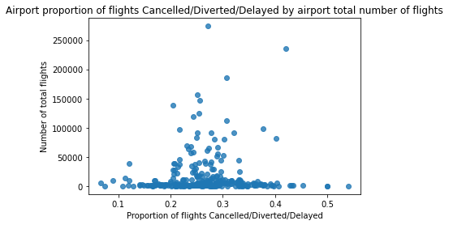

```python
sb.regplot(data = airportdf, x = '0_y', y = '0_x', fit_reg = False)
plt.xlabel('Proportion of flights Cancelled/Diverted/Delayed')
plt.ylabel('Number of total flights')
plt.title('Airport proportion of flights Cancelled/Diverted/Delayed by airport total number of flights');
```

- The best and worst airports in terms of proportion of flights Cancelled/Diverted/Delayed tend to be smaller, while bigger airports are typically mid-ranged

```python
pfba_best = pfba_prop.sort_values(ascending = False).index[-5:]
pfba_worst = pfba_prop.sort_values(ascending = False).index[0:5]
```

```python
pfba_bestandworst
```

```
Index(['PLN', 'AKN', 'DLG', 'MQT', 'SPI', 'OGG', 'LWS', 'LIH', 'BLI', 'ITO'], dtype='object')
```

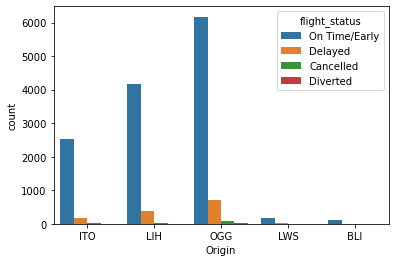

```python
sb.countplot(data = flights[flights['Origin'].isin(pfba_best)], x = 'Origin', hue = 'flight_status')
```

- Airports with the best record of On Time/ Early flights are not unianimously large or small, 3 of the top 5 encounter heavy air traffic, while 2 are much smaller airports

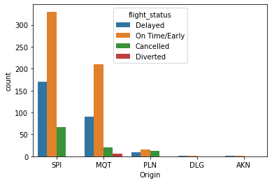

```python
sb.countplot(data = flights[flights['Origin'].isin(pfba_worst)], x = 'Origin', hue = 'flight_status')
```

- Three of the top 5 worst airports for Cancelled/Diverted/Delayed flights are in the Midwest and the other two are in Alaska. Climate probably plays a big factor in whether or not their are delays. Size was again split between big and small

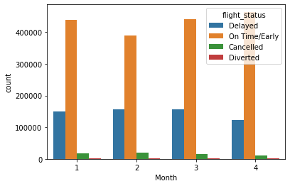

```python
sb.countplot(data = flights, x = 'Month', hue = 'flight_status');
```

- With only four months of data for 2008, it would be tough to find trends in the differences between number of each flight type status. This clustered bar chart doesn't point to a significant change in each flight status category per month

[figure not shown]

```python
g = sb.FacetGrid(data = flights, col = 'UniqueCarrier', col_wrap = 5)
[plt.setp(ax.get_xticklabels(), rotation=45) for ax in g.axes.flat]
g.map(sb.countplot, 'flight_status');
```

## Multivariate Exploration

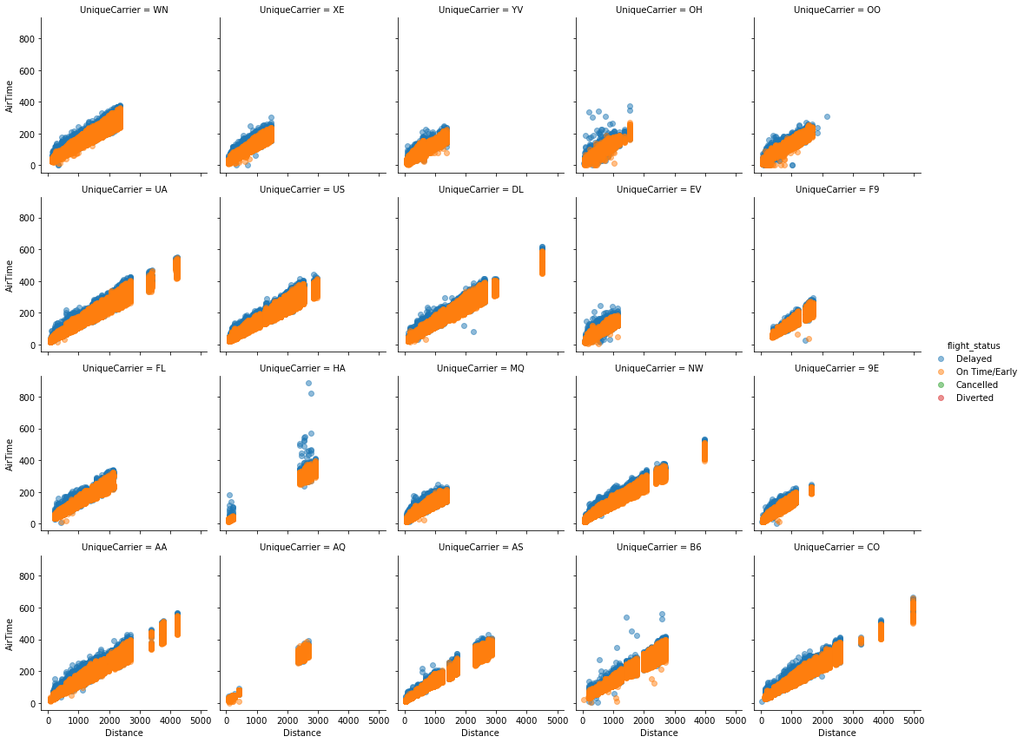

```python
g = sb.FacetGrid(data = flights, col = 'UniqueCarrier', col_wrap = 5, hue = 'flight_status')
g = g.map(plt.scatter, 'Distance', 'AirTime', alpha = .5)
g.add_legend();
```

- The Carrier HA has a record of some delayed flights being in the air much longer than they should be proportional to their distance. If I was looking to book a flight that needs to be on time, I would shy away from this carrier

### Talk about some of the relationships you observed in this part of the investigation. Were there features that strengthened each other in terms of looking at your feature(s) of interest?

I extended my investigation of flight_status against distance and AirTime in this section by looking at the impact of the three categorical quality features.

### Conclusion

When considering what factors contribute most to whether or not a flight will be delayed, the most important thing to factor is which airline carrier you will be using. Some carriers have great records for getting passengers to their destinations on time, while others have a record of increased cancelled, delayed, or diverted flights. Airtime and distance seem to not affect the proportion of flights that are Cancelled, Diverted, or Delayed.